# Stats 506, F18, Problem Set 3

Xun Wang, xunwang@umich.edu

Novmber 3,2018

## Question 1: Including Plots

### Question 1 Part a

**Table 1.** Proportion of homes with stucco construction within each census division in 2015. Estimates are based on the residential energy consumption survey.

| Divisions | %Stucco Homes(95% CI) |
| --- | --- |
| Mountain South | 64.248(55.447,73.048) |
| Pacific | 44.586(41.279,47.893) |
| Mountain North | 16.606(10.249,22.962) |
| South Atlantic | 10.620(7.835,13.405) |
| West North Central | 4.866(0.891,8.840) |
| West South Central | 2.987(1.627,4.348) |
| Middle Atlantic | 2.062(0.622,3.501) |
| New England | 1.227(0.000,2.797) |
| East North Central | 0.657(0.101,1.212) |
| East South Central | 0.423(0.000,1.225) |

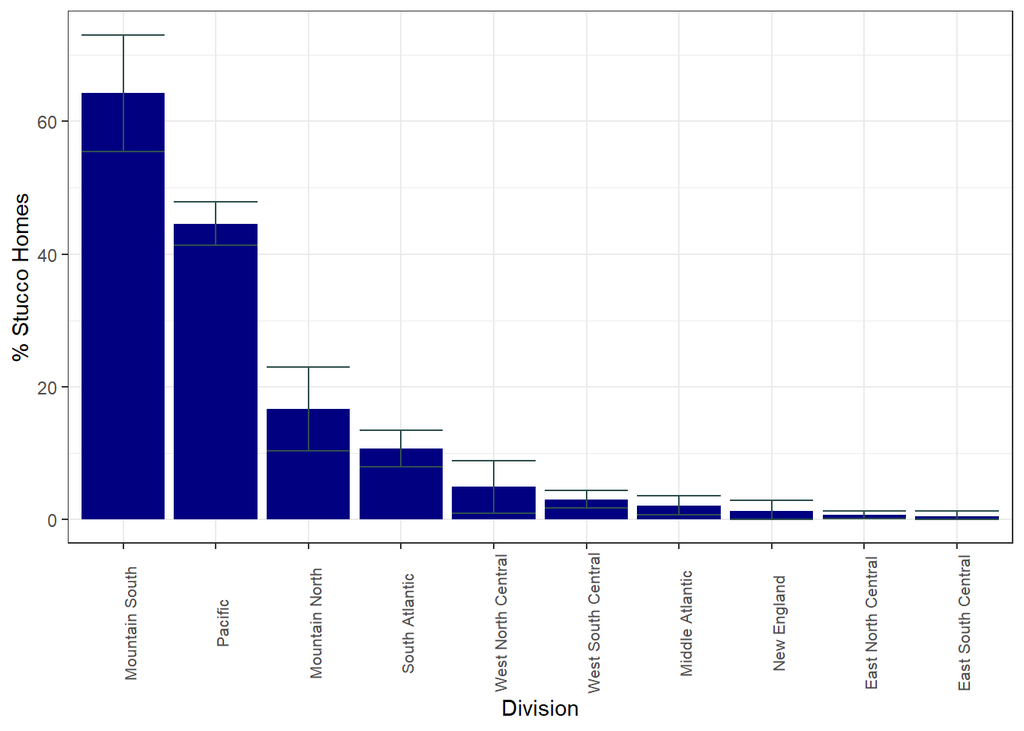

**Figure 1.** Estimated percent of homes within each division with major wall type of stucco.

From the table above, we could see percent of homes having stucco construction as their major outside wall material within each division. Obviously, Mountain South had the largest proportion of stucco homes and East South Central had the lowest percent, which are 64.248(55.447,73.048) and 0.423(0.000,1.225).

### Question 1 Part b

The table 2 below shows the average total electricity usage in kilowatt hours in each division.

**Table 2.** Average annual electricity utilization by Census Division in kwh/home.

| Division | Average Electricity Usage/kwh(95% CI) |
| --- | --- |
| East South Central | 14535.969(13319.555,15752.383) |
| West South Central | 14324.259(13495.111,15153.407) |
| South Atlantic | 13446.621(12903.940,13989.302) |
| West North Central | 10523.828(9634.741,11412.915) |
| Mountain South | 10442.017(7950.126,12933.908) |
| East North Central | 9128.663(8729.563,9527.763) |
| Middle Atlantic | 8465.442(8071.303,8859.581) |
| Mountain North | 8384.471(7121.413,9647.528) |
| Pacific | 8100.405(7750.361,8450.449) |
| New England | 7514.561(6471.828,8557.295) |

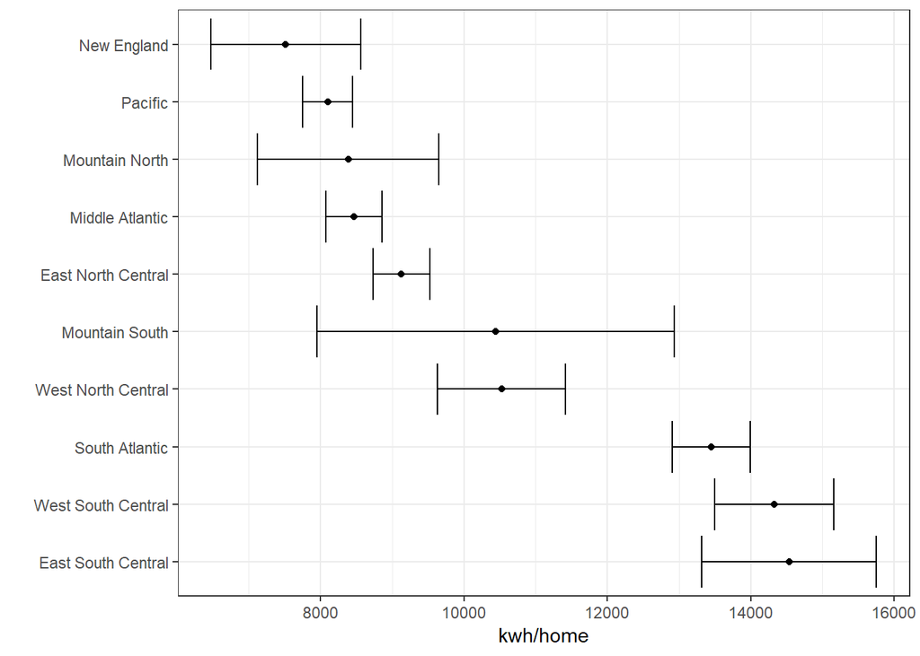

**Figure 2.** Estimated average annual electricity usage in khw/home for each of 10 census divisions.

The result stratified by urban and rural status is displayed in table 3.

**Table 3.** Average electricity utilization in kwh per home for urban and rural areas witihin each census division.

| Division | Rural Usage/kwh(95% CI) | Urban Usage/kwh(95% CI) |
| --- | --- | --- |
| East South Central | 16332.679(14087.522,18577.837) | 13747.306(12196.555,15298.058) |
| West South Central | 16317.160(14067.109,18567.211) | 13628.515(12851.964,14405.066) |
| South Atlantic | 15941.991(14838.618,17045.365) | 12724.598(12133.693,13315.503) |
| West North Central | 14173.932(12608.245,15739.619) | 9466.522(8722.062,10210.983) |
| Pacific | 14114.760(12000.927,16228.592) | 7348.878(6904.741,7793.015) |
| East North Central | 13500.024(12021.690,14978.357) | 7980.067(7552.402,8407.732) |
| Middle Atlantic | 12223.389(10632.983,13813.795) | 7987.288(7658.785,8315.792) |
| Mountain North | 9356.001(5698.153,13013.850) | 8099.379(7396.125,8802.634) |
| New England | 9001.054(6766.076,11236.032) | 6963.862(5917.635,8010.088) |
| Mountain South | 8610.426(6536.222,10684.630) | 10742.906(8178.035,13307.777) |

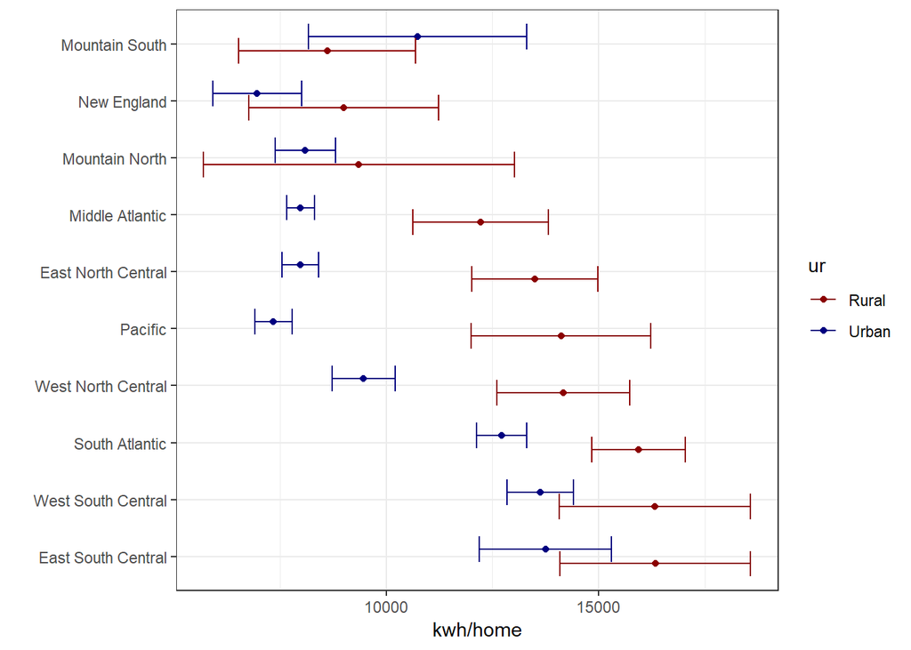

**Figure 3.** Average electricity utilization in kwh per home for urban and rural areas witihin each census division.

### Question 1 Part c

In order to get the largest disparity between these proportions, we calculate the proportion of homes with internet access of urban and rural areas first, and the BBR standard error to estimate these proportions repectively.And then we get their disparity through spreading the table.

**Table 4.** Urban and rural disparity in internet access for the ten US Census Division in 2015.

[output not shown]

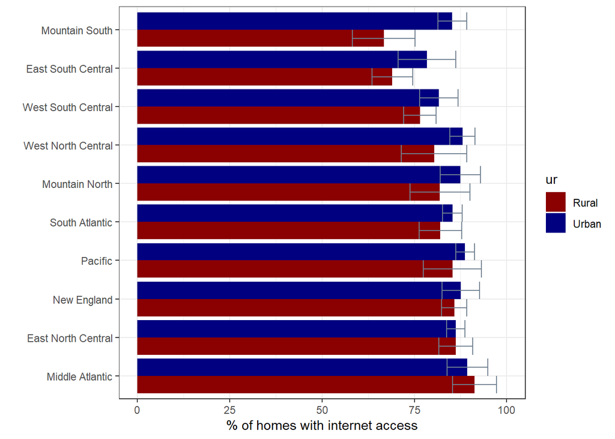

**Figure 4.** Urban and rural disparity in internet access for the ten US Census Division in 2015.

The largest disparity happened in Mountain South division and there is an 18.5% disparity between Urban and Rural internet access. This is approximately twice as large as the next largest estimated disparity and the only estimate whose confidence interval does not include zero.

### Question 1 Part d

Question d: What proportion of homes have on-site electricity generation from solar within each division? Stratified by urban and rural status.

**Table 5.** Urban and rural proportions in on-site electricity generation from solar for US Census Divisions in 2015.

| Division | Rural Solar Proportion(95% CI) | Urban Solar Porportion(95% CI) |
| --- | --- | --- |
| Pacific | 7.088(1.427,12.750) | 4.367(2.779,5.955) |
| Mountain North | 3.178(0.663,5.692) | 3.521(0.000,9.387) |
| Mountain South | 2.670(0.000,8.355) | 3.281(1.560,5.003) |
| New England | 2.185(0.208,4.162) | 2.645(0.000,6.321) |
| South Atlantic | 1.394(0.057,2.731) | 0.188(0.000,0.583) |
| East North Central | 1.000(0.000,2.526) | 0.000(0.000,0.000) |
| West South Central | 0.722(0.000,1.970) | 1.422(0.726,2.119) |
| Middle Atlantic | 0.000(0.000,0.000) | 3.869(0.696,7.042) |
| East South Central | 0.000(0.000,0.000) | 0.000(0.000,0.000) |
| West North Central | 0.000(0.000,0.000) | 0.000(0.000,0.000) |

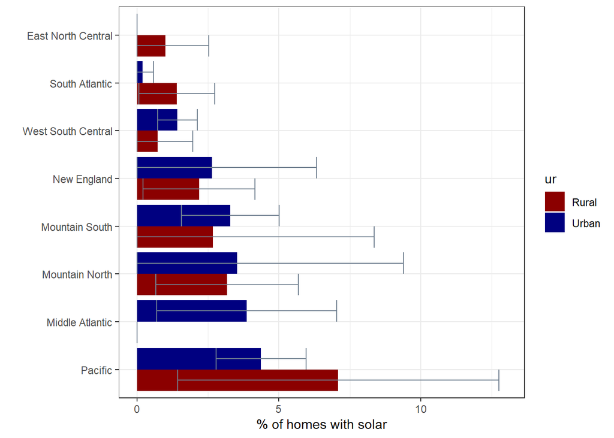

**Figure 5.** Urban and rural proportions in on-site electricity generation from solar for US Census Divisions in 2015 by excluding some NA values.

## Question 2: Including Plots

### Question 2 Part a

We write the function p_value to accepts matrices X and beta and returns a p by mc_rep matrix of p-values corresponding to the test in this question. The function is:

```r
p_value=function(X,beta,sigma,mc_rep){

  ##because epsilon are independent
  set.seed(77)
  epsilon=rnorm(n*mc_rep,0,sigma)
  Y=epsilon+as.vector(X%*%beta)
  dim(Y)=c(n,mc_rep)
  QR=qr(t(X)%*%X)

  ##i.estimate of beta
  beta_est=solve(qr.R(QR),t(qr.Q(QR))%*%t(X)%*%Y)

  ##ii.estimate of the error variance
  resids=Y-X%*%beta_est
  sigma_square_est=(1/(n-p))*diag(t(resids)%*%(resids))

  ##iii.the variance of the estimate of beta
  v=diag(chol2inv(chol(t(X)%*%X)))
  dim(v)=c(p,1)
  dim(sigma_square_est)=c(1,mc_rep)
  var_beta=v%*%sigma_square_est

  ##iv.compute p-values
  Z=beta_est/sqrt(var_beta)
  p=2*(1-pnorm(abs(Z)))
  p
}
```

And then we test this function by assigning mc_rep=1. In this case, we use the Cholesky factorization to generate X with variance matrix which has elements in 77 by 7 and 7 by 77position, and we also assign sigma=7. And then comparing the result to the result summarized by lm(Y ~ 0 + X). Becasue this table is very long, we just put first severals rows.

**Table 6.**p-values computed by the function and lm method, and their differences.

| Estimate | Std. Error | t value | pvalues_lm | pvalues_fun | Differences |
| --- | --- | --- | --- | --- | --- |
| 1.120 | 0.239 | 4.694 | 0.000 | 0.000 | 0 |
| 1.229 | 0.225 | 5.463 | 0.000 | 0.000 | 0 |
| 1.269 | 0.230 | 5.509 | 0.000 | 0.000 | 0 |
| 0.607 | 0.231 | 2.623 | 0.009 | 0.009 | 0 |
| 0.781 | 0.236 | 3.317 | 0.001 | 0.001 | 0 |
| 0.783 | 0.218 | 3.594 | 0.000 | 0.000 | 0 |

Use which function to see if there is any difference is larger than 1e-3

```r
which(abs(table_2$difference)>0.001)
```

```
## integer(0)
```

So the function passes the test.

### Question 2 Part b

We choose the same variance of X and sigma in part a. And then assume mc_rep =1000, we could get a p by mc_rep=100*1000 dimensional matrix of p-values by passing these parameters to the function in part a.

```r
dim(pvalues)
```

```
## [1]  100 1000
```

### Question 2 Part c

The function is:

```r
evaluate=function(pvalues,non_zero_index){

  ###the family wise error rate is type 1 error of H0:beta_i=0
  zero_index=c(1:length(beta))[-non_zero_index]
  V=colSums(pvalues[zero_index,]<=0.05)
  fwer=sum(V>=1)/dim(pvalues)[2]

  ###the false discovery rate is the expectation of the proportion of false
  ###discoveries among the discoveries
  S=colSums(pvalues[non_zero_index,]<=0.05)
  fdr=sum(V/(V+S))/dim(pvalues)[2]

  ###the sensitivity is N(true positive)/(N(true positive)+N(false negatives))
  fn=colSums(pvalues[non_zero_index,]>0.05)
  sensitivity=sum(S/(S+fn))/dim(pvalues)[2]

  ###the specificity is N(true negatives)/(N(true negatives)+N(false positives))
  U=colSums(pvalues[zero_index,]>0.05)
  specificity=sum(U/(U+V))/dim(pvalues)[2]

  v=c(fwer,fdr,sensitivity,specificity)
  names(v)=c("family wise error rate","false discovery rate",
             "sensitivity","specificity")
  v
}
```

### Question 2 Part d&e

Apply our evaluate function to the matrix of p-values matrix, we get five groups of family wise error rate, false discovery rate, sensitivity and specificity quantities, which are before adjust and adjusted by Bonferroni, Holm,BH and BY methods. We combine them into one table.

**Table 7.**Four quantities computed using different methods.

|  | family wise error rate | false discovery rate | sensitivity | specificity |
| --- | --- | --- | --- | --- |
| before_adjust | 0.989 | 0.303 | 0.978 | 0.949 |
| bonferroni_evaluate | 0.058 | 0.007 | 0.732 | 0.999 |
| holm_evaluate | 0.061 | 0.008 | 0.736 | 0.999 |
| BH_evaluate | 0.379 | 0.048 | 0.889 | 0.994 |
| BY_evaluate | 0.085 | 0.010 | 0.766 | 0.999 |

We caould also draw a graph of these quantities.

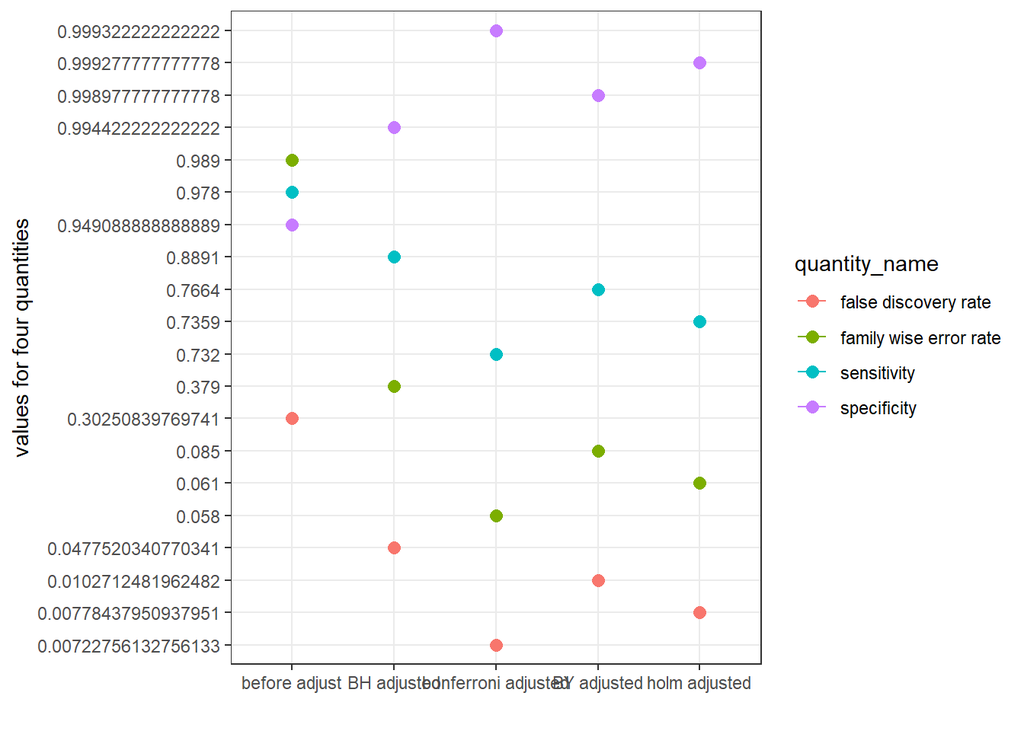

**Figure 6.** .Four quantities computed using different methods.

## Question 3: Including Plots

### Question 3 Part a

The translation of data.table is as following:

```r
dt=as.data.table(mtcars)
dt=dt%>%
  .[,.(mpg,cyl,disp,hp,wt)]
beta_cyl=dt%>%

  ##compute centered variables, cross product with mpg, and squares.
  .[,`:=`(disp_gc=disp-mean(disp),hp_gc=hp-mean(hp),wt_gc=wt-mean(wt)),
    by=.(cyl)]%>%
  .[,`:=`(dispXmpg=mpg*disp_gc,hpXmpg=mpg*hp_gc,wtXmpg=mpg*wt_gc,
    disp_sq=disp_gc*disp_gc,hp_sq=hp_gc*hp_gc,wt_sq=wt_gc*wt_gc),
    by=.(cyl)]%>%

  ##Compute the cross products, sum of squares, and regression coefficients
  .[,.(dispXmpg=sum(dispXmpg),disp_sq=sum(disp_sq),
       hpXmpg=sum(hpXmpg),hp_sq=sum(hp_sq),
       wtXmpg=sum(wtXmpg),wt_sq=sum(wt_sq)),
    by=.(cyl)]%>%

  ##Compute betas
  .[,`:=`(beta_cyl_disp=dispXmpg/disp_sq,
          beta_cyl_hp=hpXmpg/hp_sq,
          beta_cyl_wt=wtXmpg/wt_sq),
    by=.(cyl)]%>%
  .[,-c("dispXmpg","disp_sq","hpXmpg","hp_sq","wtXmpg","wt_sq")]
##save as new file
fwrite(beta_cyl,file='mpg_cor_by_cyl.csv')
```

### Question 3 Part b

```r
uni_reg=function(y,x,group){
  beta_group=as.data.table(cbind(y,x,group))%>%
    .[,x_gc:=x-mean(x),group]%>%
    .[,`:=`(xXy=y*x_gc,x_sq=x_gc*x_gc),group]%>%
    .[,.(xXy=sum(xXy),x_sq=sum(x_sq)),group]%>%
    .[,beta_group_x:=xXy/x_sq,group]%>%
    .[,-c("xXy","x_sq")]
  beta_group
}
```

Then we test our function uni_reg.

**Table 8.**Compute univariate regression coefficient by group using function.

| cyl | beta_disp | cyl | beta_hp | cyl | beta_wt |
| --- | --- | --- | --- | --- | --- |
| 6 | 0.004 | 6 | -0.008 | 6 | -2.780 |
| 4 | -0.135 | 4 | -0.113 | 4 | -5.647 |
| 8 | -0.020 | 8 | -0.014 | 8 | -2.192 |

It is the same with the result computed in part a.

**Table 9.**Compute univariate regression coefficient by group in part a

| cyl | beta_cyl_disp | beta_cyl_hp | beta_cyl_wt |
| --- | --- | --- | --- |
| 6 | 0.004 | -0.008 | -2.780 |
| 4 | -0.135 | -0.113 | -5.647 |
| 8 | -0.020 | -0.014 | -2.192 |

So, the function uni_reg passes the test.

### Question 3 Part c

**Table 10.**Compute univariate regression coefficient by group using summarize_at

| cyl | beta_cyl_disp | beta_cyl_hp | beta_cyl_wt |
| --- | --- | --- | --- |
| 4 | -0.135 | -0.113 | -5.647 |
| 6 | 0.004 | -0.008 | -2.780 |
| 8 | -0.020 | -0.014 | -2.192 |

### Question 3 Part d

**Table 11.**Compute univariate regression coefficient by group using dplyr quotes function

| cyl | dispXmpg | cyl | hpXmpg | cyl | wtXmpg |
| --- | --- | --- | --- | --- | --- |
| 4 | -0.135 | 4 | -0.113 | 4 | -5.647 |
| 6 | 0.004 | 6 | -0.008 | 6 | -2.780 |
| 8 | -0.020 | 8 | -0.014 | 8 | -2.192 |